# Skalendokumentation ‘Falllbasiertes Lernen in der ersten Phase der Lehrerbildung’

Jürgen Schneider

Aug 2016

# data cleaning

## outlier

- out of theoretical range:
  - age: 1 case

# pretest

## id

Serial number of subject. Coming from two datasets, these numbers may not be unique for each person. In order to destinguish subjects use **code**.

## submit date

T1_submitdate: Date and time when online questionnaire was submitted.

## date stamp

T1_datestamp: Date and time of last activity. Equals **T1_submitdate**, when questinnaire was successfully finished.

## start date

T1_startdate: Date and time when online questionnaire was started.

## Identification code

- source: own creation
- question type: open answer
- number of items: 5
- names and label of items:
  - id_1: out of anonymity reasons we do not publish this item label
  - id_2: out of anonymity reasons we do not publish this item label
  - id_3: out of anonymity reasons we do not publish this item label
  - id_4: out of anonymity reasons we do not publish this item label
  - id_5: out of anonymity reasons we do not publish this item label
- identification code items have been pasted together into the variable **code**

## Participation in pre and post test

- source: own coding
- question type: automated coding by researcher
- number of items: 1
- names and label of items:
  - pre_post
- value lables and numbers:
  - 0 = participated in pre **or** posttest (but not both)
  - 1 = participated in pre **and** posttest

## age

- source: own creation
- question type: open answer
- number of items: 1
- names and label of items:
  - alter: “Alter”
- item statistics

| n | mean | sd | min | max |
| --- | --- | --- | --- | --- |
| 638 | 21 | 2.35 | 18 | 51 |

- frequency plot

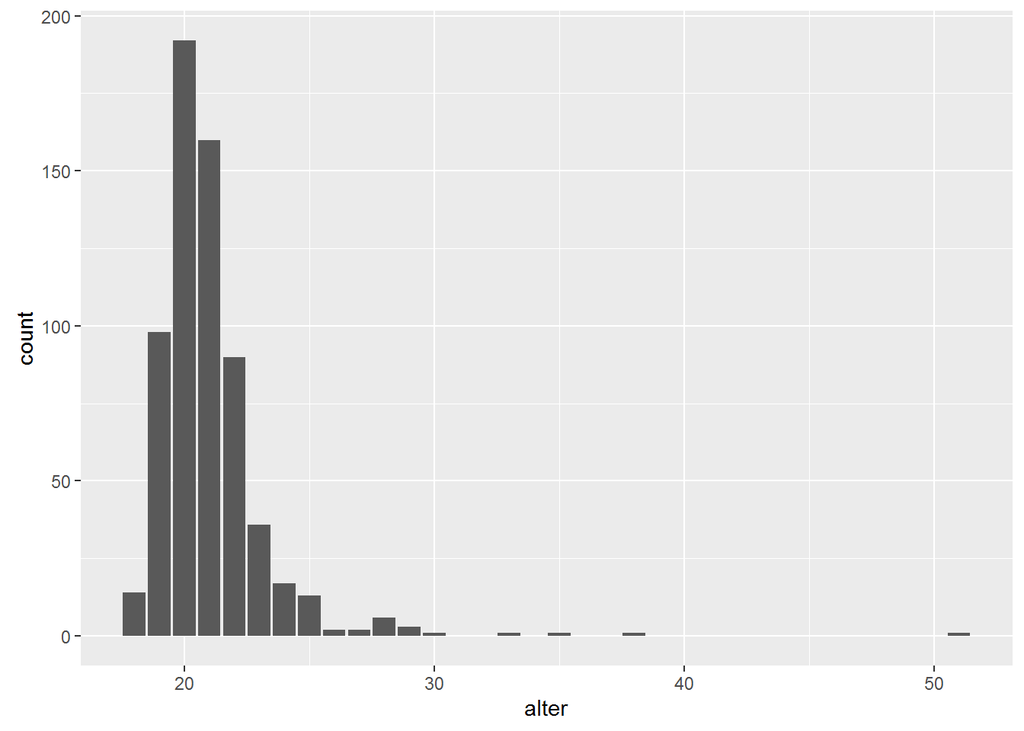

## sex

- source: own creation
- question type: single choice
- number of items: 1
- names and label of items:
  - geschl__: “Geschlecht”
- value lables and numbers:
  - 1 = “weiblich”
  - 2 = “männlich”
  - 3 = “sonstige”
- item statistics

| n | female | male | other |
| --- | --- | --- | --- |
| 642 | 424 | 217 | 1 |

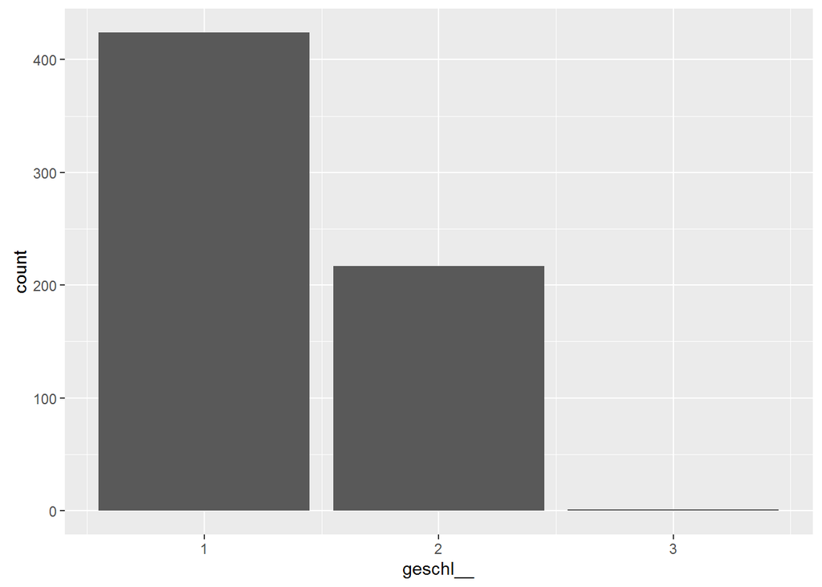

## course

States which of the 21 courses (that participated in the study) the student attended. May be useful as a cluster variable for multilevel analyses.

- source: own creation
- question type: drop down menu
- number of items: 1
- names and label of items:
  - geschl__: “Ich besuche das LLU-Seminar”
- value lables and numbers:
  - 1 = out of anonymity reasons we do not publish this item label
  - 2 = out of anonymity reasons we do not publish this item label
  - 3 = out of anonymity reasons we do not publish this item label
  - 4 = out of anonymity reasons we do not publish this item label
  - 5 = out of anonymity reasons we do not publish this item label
  - 6 = out of anonymity reasons we do not publish this item label
  - 7 = out of anonymity reasons we do not publish this item label
  - 8 = out of anonymity reasons we do not publish this item label
  - 9 = out of anonymity reasons we do not publish this item label
  - 10 = out of anonymity reasons we do not publish this item label
  - 11 = out of anonymity reasons we do not publish this item label
  - 12 = out of anonymity reasons we do not publish this item label
  - 13 = out of anonymity reasons we do not publish this item label
  - 14 = out of anonymity reasons we do not publish this item label
  - 15 = out of anonymity reasons we do not publish this item label
  - 16 = out of anonymity reasons we do not publish this item label
  - 17 = out of anonymity reasons we do not publish this item label
  - 18 = out of anonymity reasons we do not publish this item label
  - 19 = out of anonymity reasons we do not publish this item label
  - 20 = out of anonymity reasons we do not publish this item label
  - 21 = out of anonymity reasons we do not publish this item label
- item statistics

| 1 | 2 | 3 | 4 | 5 | 6 | 7 | 8 | 9 | 10 | 11 | 12 | 13 | 14 | 15 | 16 | 17 | 18 | 19 | 20 | 21 |
| --- | --- | --- | --- | --- | --- | --- | --- | --- | --- | --- | --- | --- | --- | --- | --- | --- | --- | --- | --- | --- |
| 28 | 35 | 33 | 31 | 29 | 33 | 28 | 27 | 30 | 34 | 31 | 26 | 31 | 36 | 33 | 31 | 34 | 31 | 29 | 26 | 24 |

## treatment

Indicates which treatment the participant received. As we had 21 courses distributuion could not be even and the text*pol was thus taught in 6 courses.

- source: own coding
- question type: automated coding by researcher
- number of items: 1
- names and label of items:
  - seminartyp
- value lables and numbers:
  - 1 = **video** based cases with **problem oriented learning**
  - 2 = **video** based cases with **direct instruction**
  - 3 = **text** based cases with **problem oriented learning**
  - 4 = **text** based cases with **direct instruction**
- item statistics

| 1 | 2 | 3 | 4 |
| --- | --- | --- | --- |
| 155 | 152 | 179 | 154 |

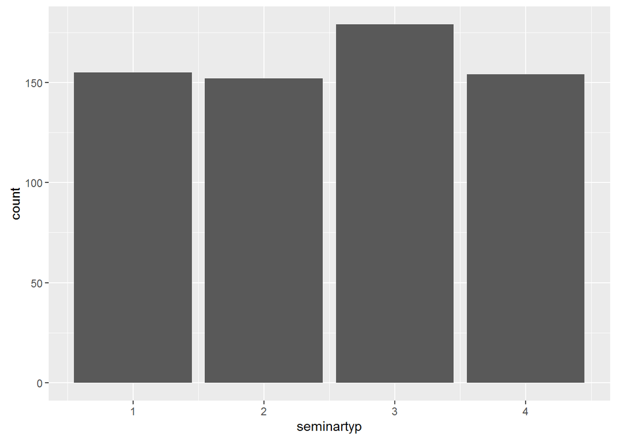

## Subject

Indicates which subject the participant is studying to be teaching.

- source: own creation
- question type: multiple choice with ‘other’ text field at the end
- number of items: 24
- names and label of items:
  - untf_1 = “Ich studiere folgende Unterrichtsfächer: **Biologie**”
  - untf_2 = “Ich studiere folgende Unterrichtsfächer: **Chemie**”
  - untf_3 = “Ich studiere folgende Unterrichtsfächer: **Deutsch**”
  - untf_4 = “Ich studiere folgende Unterrichtsfächer: **Englisch**”
  - untf_5 = “Ich studiere folgende Unterrichtsfächer: **Erziehungswissenschaft**”
  - untf_6 = “Ich studiere folgende Unterrichtsfächer: **Evangelische Theologie**”
  - untf_7 = “Ich studiere folgende Unterrichtsfächer: **Französisch**”
  - untf_8 = “Ich studiere folgende Unterrichtsfächer: **Geographie**”
  - untf_9 = “Ich studiere folgende Unterrichtsfächer: **Geschichte**”
  - untf_10 = “Ich studiere folgende Unterrichtsfächer: **Griechisch**”
  - untf_11 = “Ich studiere folgende Unterrichtsfächer: **Informatik**”
  - untf_12 = “Ich studiere folgende Unterrichtsfächer: **Italienisch**”
  - untf_13 = “Ich studiere folgende Unterrichtsfächer: **Katholische Theologie**”
  - untf_14 = “Ich studiere folgende Unterrichtsfächer: **Latein**”
  - untf_15 = “Ich studiere folgende Unterrichtsfächer: **Mathematik**”
  - untf_16 = “Ich studiere folgende Unterrichtsfächer: **Naturwissenschaft und Technik**”
  - untf_17 = “Ich studiere folgende Unterrichtsfächer: **Philosophie / Ethik**”
  - untf_18 = “Ich studiere folgende Unterrichtsfächer: **Physik**”
  - untf_19 = “Ich studiere folgende Unterrichtsfächer: **Politikwissenschaft / Wirtschaftswissenschaft**”
  - untf_20 = “Ich studiere folgende Unterrichtsfächer: **Russisch**”
  - untf_21 = “Ich studiere folgende Unterrichtsfächer: **Spanisch**”
  - untf_22 = “Ich studiere folgende Unterrichtsfächer: **Sport**”
  - untf_23 = “Ich studiere folgende Unterrichtsfächer: **Islamische Theologie**”
  - untf_other = “Ich studiere folgende Unterrichtsfächer: **Sonstiges**”
- value lables and numbers:
  - 0 = not selected
  - 1 = selected
- item statistics

| subject | frequency |
| --- | --- |
| untf_01 | 46 |
| untf_02 | 39 |
| untf_03 | 165 |
| untf_04 | 208 |
| untf_05 | 14 |
| untf_06 | 46 |
| untf_07 | 72 |
| untf_08 | 51 |
| untf_09 | 153 |
| untf_10 | 4 |
| untf_11 | 2 |
| untf_12 | 19 |
| untf_13 | 37 |
| untf_14 | 36 |
| untf_15 | 112 |
| untf_16 | 12 |
| untf_17 | 74 |
| untf_18 | 30 |
| untf_19 | 32 |
| untf_20 | 12 |
| untf_21 | 75 |
| untf_22 | 40 |
| untf_23 | 0 |
| untf_other | 22 |

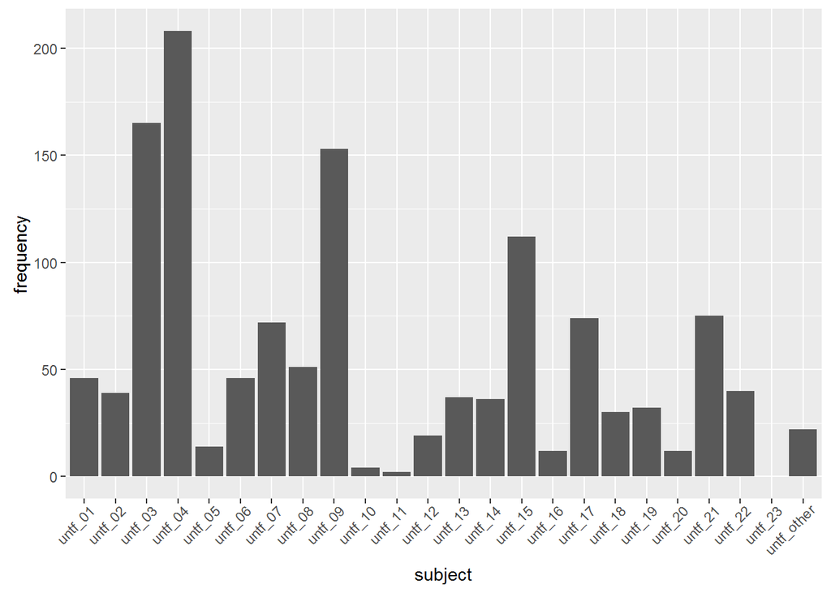

## semester

Indicates how many semesters the participant studied.

- source: own creation
- question type: number question
- number of items: 1
- names and label of items:
  - semester: “Ich befinde mich im … Fachsemester.”
- item statistics

| n | mean | sd | min | max |
| --- | --- | --- | --- | --- |
| 646 | 2.63 | 1.33 | 1 | 12 |

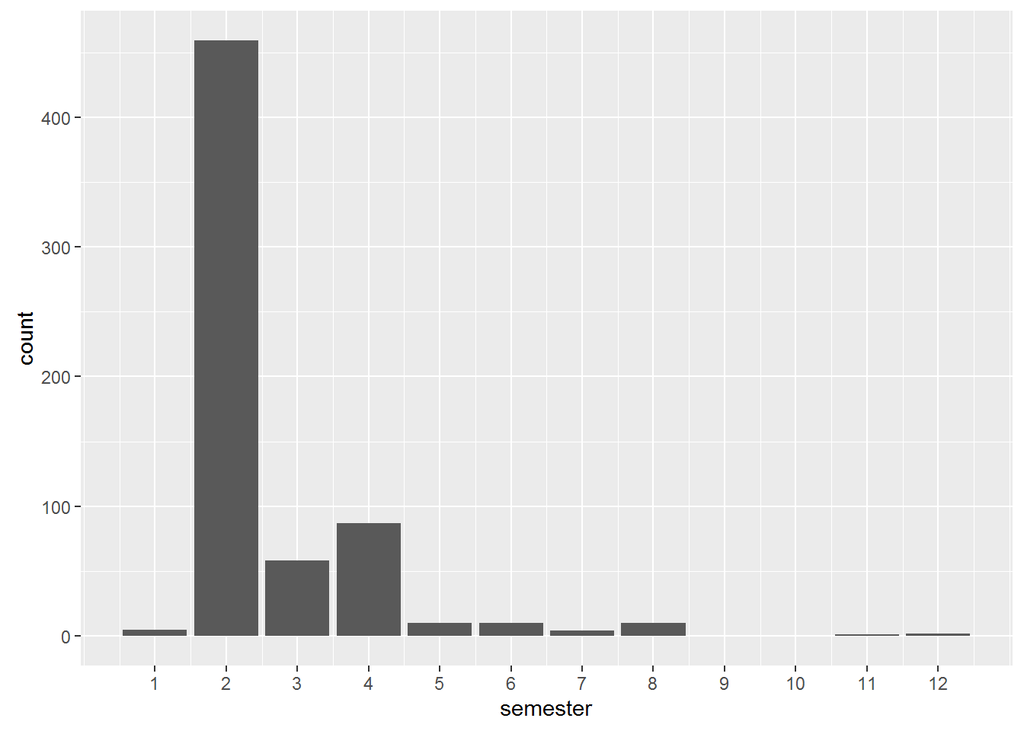

## classroom lessons taught

Indicates how many 45min classroom lessons the participant taught already.

- source: own creation
- question type: number question
- number of items: 1
- names and label of items:
  - unterrichtet: “Ich habe bereits ca. … Unterrichtsstunden selbst unterrichtet.”
- item statistics

| n | mean | sd | min | max |
| --- | --- | --- | --- | --- |
| 636 | 23.6 | 362 | 0 | 9000 |

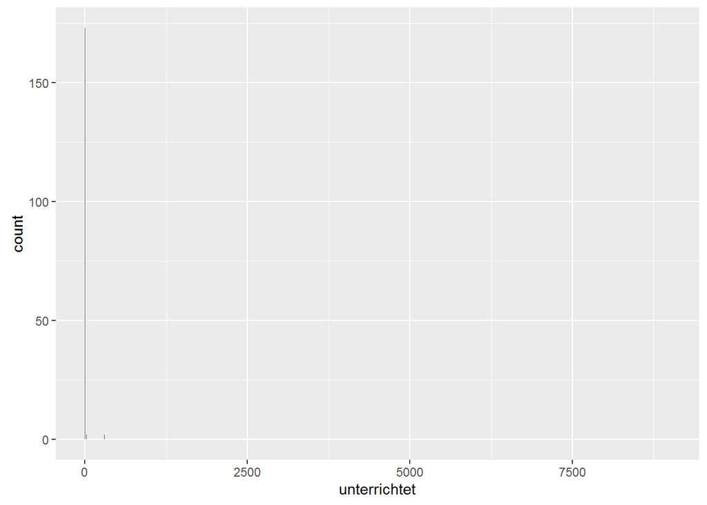

The exact numbers are:

| lessons taught | frequency |
| --- | --- |
| 0 | 173 |
| 1 | 74 |
| 2 | 105 |
| 3 | 48 |
| 4 | 48 |
| 5 | 49 |
| 6 | 21 |
| 7 | 3 |
| 8 | 15 |
| 9 | 1 |
| 10 | 32 |
| 12 | 7 |
| 14 | 1 |
| 15 | 3 |
| 16 | 1 |
| 20 | 16 |
| 24 | 2 |
| 25 | 2 |
| 30 | 9 |
| 35 | 2 |
| 36 | 1 |
| 40 | 7 |
| 50 | 4 |
| 60 | 3 |
| 100 | 1 |
| 150 | 2 |
| 200 | 1 |
| 250 | 1 |
| 300 | 2 |
| 1500 | 1 |
| 9000 | 1 |

## choice of specific course

Indicates the reason, why the participant chose the course they attended. Students were free to pick three prefered (out of the 21) courses and were then distributed via the university’s management system.

- source: own creation
- question type: multiple choice with ‘other’ text field at the end
- number of items: 4
- names and label of items:
  - sem_wahl_ut = “Aus welchem Grund haben Sie sich für dieses konkrete LLU-Seminar (im Gegensatz zu den anderen LLU-Seminaren) entschieden? **Uhrzeit und Tag waren passend**”
  - sem_wahl_do = “Aus welchem Grund haben Sie sich für dieses konkrete LLU-Seminar (im Gegensatz zu den anderen LLU-Seminaren) entschieden? **Dozierende(r) war der Grund**”
  - sem_wahl_fr = “Aus welchem Grund haben Sie sich für dieses konkrete LLU-Seminar (im Gegensatz zu den anderen LLU-Seminaren) entschieden? **Freunde/Bekannte wählten dasselbe Seminar**”
  - sem_wahl_other = “Aus welchem Grund haben Sie sich für dieses konkrete LLU-Seminar (im Gegensatz zu den anderen LLU-Seminaren) entschieden? **Sonstiges**”
- value lables and numbers:
  - 0 = not selected
  - 1 = selected
- item statistics

| reason | frequency |
| --- | --- |
| sem_wahl_ut | 573 |
| sem_wahl_do | 109 |
| sem_wahl_fr | 117 |
| sem_wahl_other | 17 |

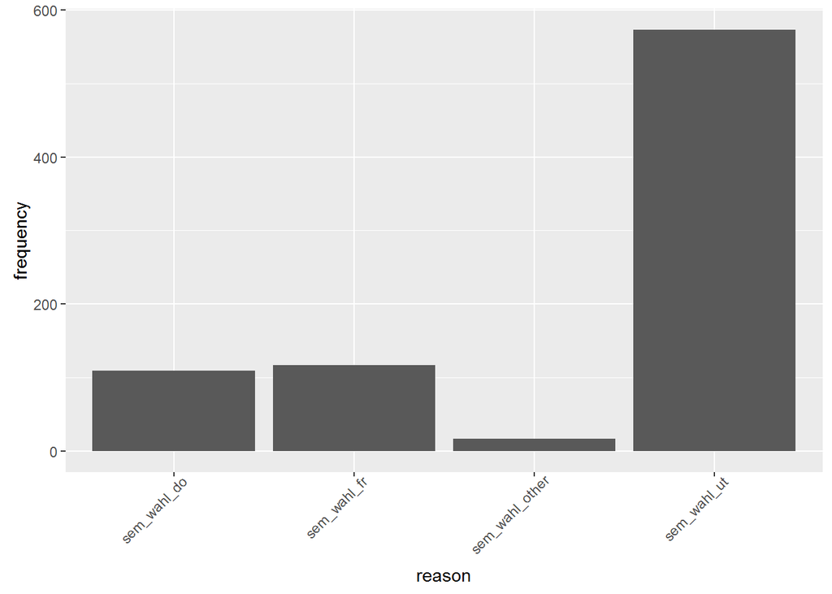

## preparatory literature read

Indicates how much of the preparatory literture the participant read (four theoretical texts).

- source: own creation
- question type: multiple choice
- number of items: 4
- names and label of items:
  - T1_text_1 = “Ich habe folgende Theorietexte bereits gelesen: **Mayr, J. (2009): Klassen stimmig führen. In: Pädagogik, 61 (2), S. 34-37.**”
  - T1_text_2 = “Ich habe folgende Theorietexte bereits gelesen: **CRM- Techniken Evertson et al in Wellenreuther 278-284.pdf**”
  - T1_text_3 = “Ich habe folgende Theorietexte bereits gelesen: **CRM-Techniken Kounin in Wellenreuther 268-274.pdf**”
  - T1_text_4 = “Ich habe folgende Theorietexte bereits gelesen: **Handlungsstrategien CRM 4 Bereiche**”
- value lables and numbers:
  - 0 = not selected
  - 1 = selected
- item statistics

| text | frequency |
| --- | --- |
| T1_text_1 | 171 |
| T1_text_2 | 73 |
| T1_text_3 | 76 |
| T1_text_4 | 39 |

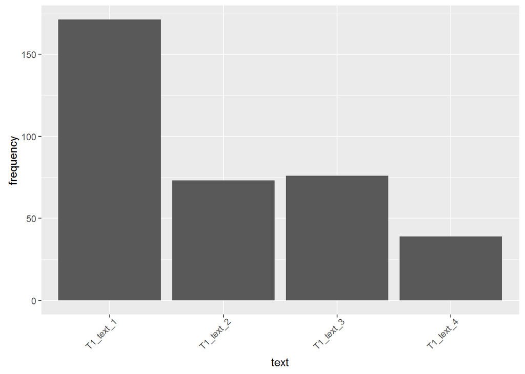

- scale statistics (sum of items used)

| n | mean | sd | min | max |
| --- | --- | --- | --- | --- |
| 647 | 0.55 | 1 | 0 | 4 |

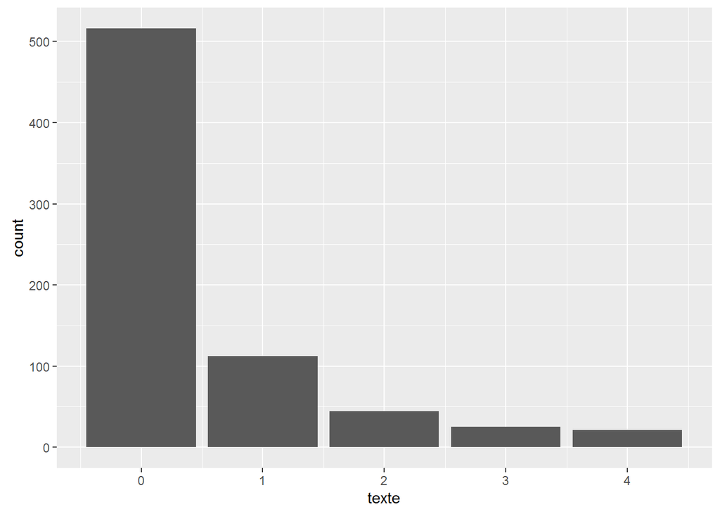

## experience in classroom analysis

Indicates how much experience the participant has concerning classroom analysis with video or text.

- source: own creation
- question type: number question
- number of items: 2
- names and label of items:
  - erf_vid = “Ich habe bereits … Veranstaltung(en) besucht, in denen auf **Video** aufgenommene Unterrichtsausschnitte analysiert wurden.”
  - erf_txt = “Ich habe bereits … Veranstaltung(en) besucht, in denen in **Textform** dargestellte Unterrichtsausschnitte analysiert wurden.”
- item statistics

| form | n | mean | sd | min | max |
| --- | --- | --- | --- | --- | --- |
| video | 632 | 2.66 | 2.55 | 0 | 30 |
| text | 609 | 1.29 | 2.14 | 0 | 30 |

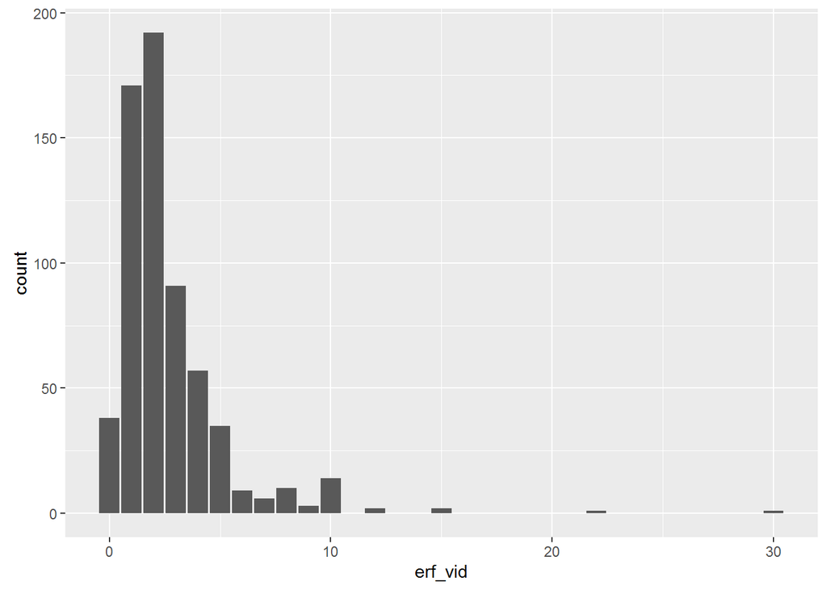

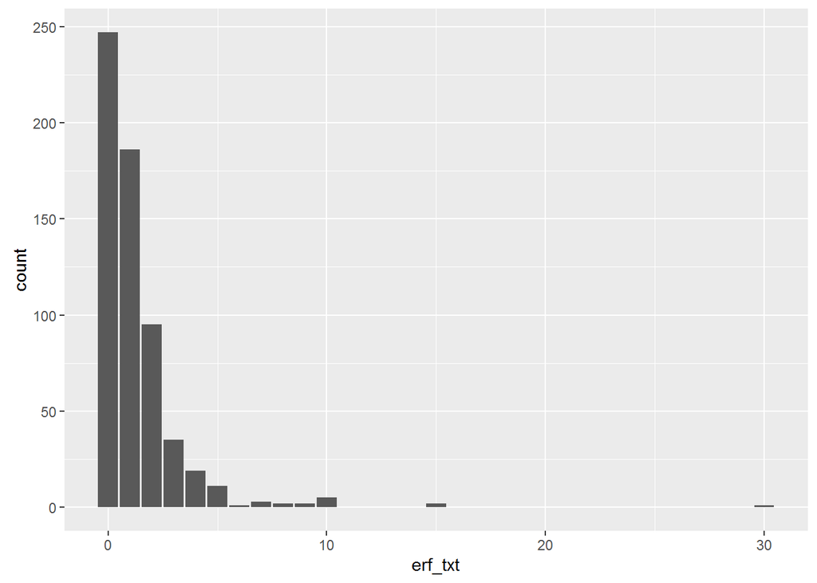

## value of classroom analysis

Indicates how much the participant values classroom analysis.

- source: own creation
- question type: likert scale
- number of items: 1
- names and label of items:
  - T1_nutz_T1 = “Wie hoch schätzen Sie den Nutzen der Analyse von Unterrichtsfällen ein?”
- value lables and numbers:
  - 1 = “sehr gering”
  - 2 = “”
  - 3 = “”
  - 4 = “sehr hoch”
- item statistics

| n | mean | sd | min | max |
| --- | --- | --- | --- | --- |
| 643 | 3.02 | 0.7 | 1 | 4 |

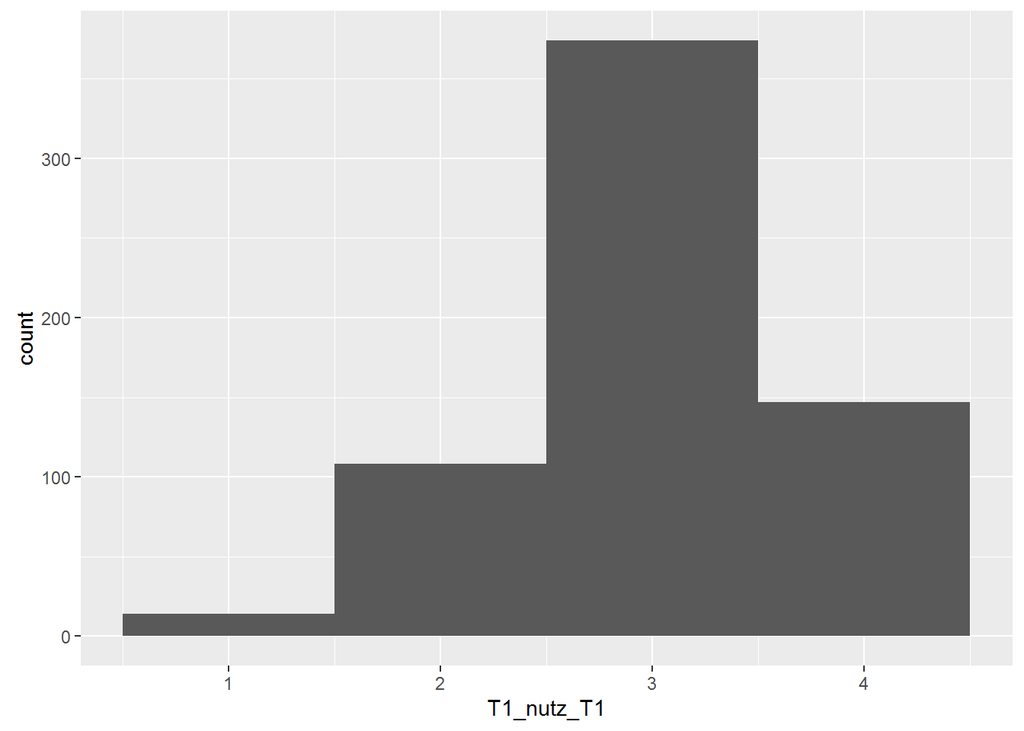

## perceived knowledge of classroom management

Indicates how high the participant estimates his/her own knowledge of classroom management.

- source: own creation
- question type: likert scale
- number of items: 1
- names and label of items:
  - T1_vorw_T1 = “Wie schätzen Sie Ihr eigenes Wissen zum Thema”Classroom Management" ein?"
- value lables and numbers:
  - 1 = “sehr gering”
  - 2 = “”
  - 3 = “”
  - 4 = “”
  - 5 = “”
  - 6 = “sehr hoch”
- item statistics

| n | mean | sd | min | max |
| --- | --- | --- | --- | --- |
| 643 | 3.04 | 1 | 1 | 6 |

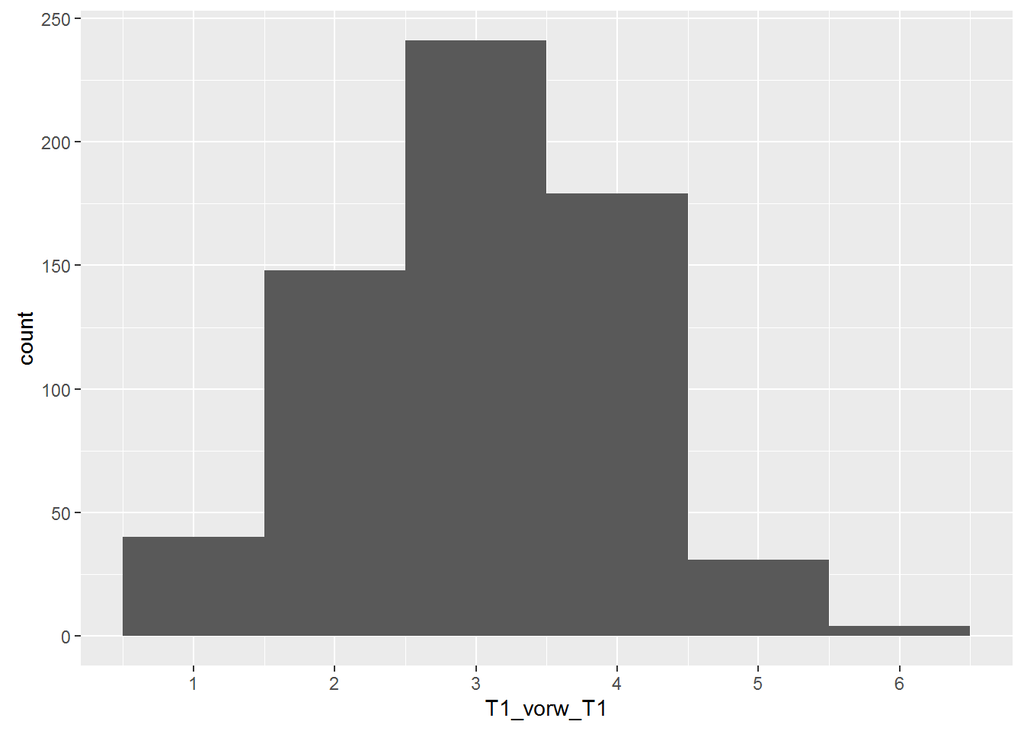

## perceived satisfaction with studying

Indicates how satisfied the participant perceives his/her own studies at the university.

- source: own creation
- question type: likert scale
- number of items: 1
- names and label of items:
  - stud_zufr = “Wie zufrieden sind Sie im Allgemeinen mit Ihrem Lehramtsstudium?”
- value lables and numbers:
  - 1 = “sehr unzufrieden”
  - 2 = “unzufrieden”
  - 3 = “weder noch”
  - 4 = “zufrieden”
  - 5 = “sehr unzufrieden”
- item statistics

| n | mean | sd | min | max |
| --- | --- | --- | --- | --- |
| 643 | 3.74 | 0.78 | 1 | 5 |

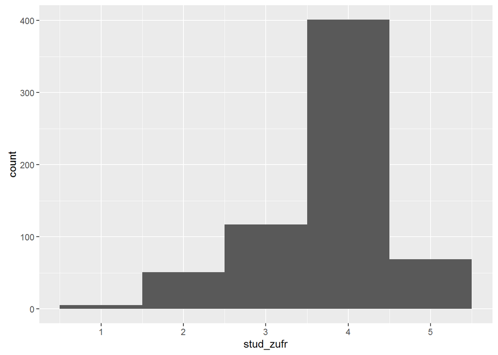

## analysis of classroom sequence

Students were asked to write analyses on three classroom sequences (1 text, 2 videos) on the topic of classroom management, using text boxes.

Screenshots of one sequence, using text:

[figure not shown]

and one using video:

[figure not shown]

The text that appeared after clicking on “Analyseschritten (hier klicken)”:

> - Was ist die Ausgangssituation?
> - Wie handelt die Lehrperson und welche weiteren Optionen gibt es?
> - Welche Ursachen/ Konsequenzen haben diese Optionen?
> - Für welche Option würden Sie sich entscheiden? Warum?
- source: own creation
- question type: open question
- number of items: 3 (1 text, 2 video sequences)
- names and label of items:
  - offen43_1: “Bitte analysieren Sie die Sequenz bezüglich der Unterrichtsgestaltung, Verhaltenskontrolle und Beziehungsgestaltung mit folgenden Analyseschritten (hier klicken)” + **Text** Sequence
  - offen43_2: “Bitte analysieren Sie die Sequenz bezüglich der Unterrichtsgestaltung, Verhaltenskontrolle und Beziehungsgestaltung mit folgenden Analyseschritten (hier klicken)” + **Video** Sequence
  - offen43_7: “Bitte analysieren Sie die Sequenz bezüglich der Unterrichtsgestaltung, Verhaltenskontrolle und Beziehungsgestaltung mit folgenden Analyseschritten (hier klicken) + **Video** Sequence”

## Emotions towards case-based learning

- source: adaption of Pekrun 1992, AEQ
- question type: likert scale
- number of items: 8
- names and label of items:
  - T1_emo_1 = “Bitte geben Sie an, wie sie sich in Lernsituationen mit Fällen ganz allgemein fühlen. **Ich eigne mir gern neues Wissen mittels Fällen an.**”
  - T1_emo_2 = “Bitte geben Sie an, wie sie sich in Lernsituationen mit Fällen ganz allgemein fühlen. **Ich blicke optimistisch auf das Lernen mit Fällen.**”
  - T1_emo_3 = “Bitte geben Sie an, wie sie sich in Lernsituationen mit Fällen ganz allgemein fühlen. **Ich bin stolz auf meine Fähigkeiten.**”
  - T1_emo_4 = “Bitte geben Sie an, wie sie sich in Lernsituationen mit Fällen ganz allgemein fühlen. **Lernen mit Fällen macht mich gereizt.**”
  - T1_emo_5 = “Bitte geben Sie an, wie sie sich in Lernsituationen mit Fällen ganz allgemein fühlen. **Ich werde angespannt und nervös beim Lernen mit Fällen.**”
  - T1_emo_6 = “Bitte geben Sie an, wie sie sich in Lernsituationen mit Fällen ganz allgemein fühlen. **Ich schäme mich, dass ich die einfachsten Sachen manchmal nicht behalten kann.**”
  - T1_emo_7 = “Bitte geben Sie an, wie sie sich in Lernsituationen mit Fällen ganz allgemein fühlen. **Ich fühle mich hilflos, wenn ich an das Lernen mit Fällen denke.**”
  - T1_emo_8 = “Bitte geben Sie an, wie sie sich in Lernsituationen mit Fällen ganz allgemein fühlen. **Lernen mit Fällen langweilt mich zu Tode.**”
- value lables and numbers:
  - 1 = “überhaupt nicht”
  - 2 = “ein wenig”
  - 3 = “ziemlich”
  - 4 = “sehr”
- inverted items: -
- subscales
  - enjoyment (Freude): T1_emo_1, T1_emo_2, T1_emo_3
  - anger (Ärger): T1_emo_4
  - anxiety (Angst): T1_emo_5, T1_emo_7
  - boredom (Langeweile): T1_emo_8
  - shame (Scham): T1_emo_6
- item statistics

| item | n | mean | sd | min | max |
| --- | --- | --- | --- | --- | --- |
| T1_emo_1 | 622 | 2.86 | 0.75 | 1 | 4 |
| T1_emo_2 | 621 | 2.89 | 0.72 | 1 | 4 |
| T1_emo_3 | 613 | 2.6 | 0.8 | 1 | 4 |
| T1_emo_4 | 617 | 1.62 | 0.74 | 1 | 4 |
| T1_emo_5 | 617 | 1.35 | 0.6 | 1 | 4 |
| T1_emo_6 | 615 | 1.52 | 0.66 | 1 | 4 |
| T1_emo_7 | 619 | 1.27 | 0.5 | 1 | 4 |
| T1_emo_8 | 617 | 1.53 | 0.71 | 1 | 4 |

- subscale statistics

| subscale | n | mean | sd | min | max |
| --- | --- | --- | --- | --- | --- |
| enjoyment | 610 | 2.79 | 0.55 | 1.33 | 4 |
| anxiety | 613 | 1.31 | 0.45 | 1 | 3 |

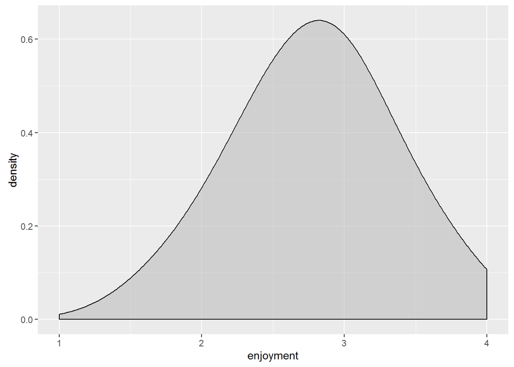

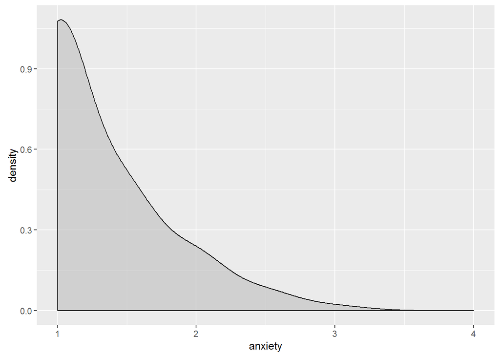

## willingness to reflect (acting)

- source: adaption of Hosenfeld, A. (2010). *Führt Unterrichtsrückmeldung zu Unterrichtsentwicklung?* Die Wirkung von videographischer und schriftlicher Rückmeldung bei Lehrkräften der vierten Jahrgangsstufe. Zugl.: Koblenz-Landau, Univ., Diss., 2009. Empirische Erziehungswissenschaft. Münster, München, Berlin: Waxmann.
- question type: likert scale
- number of items: 4
- names and label of items:
  - T1_RefBer1_1 = “Wie oft tun Sie folgende Dinge? **Ich denke darüber nach, wie ich eine Aufgabe noch besser erfüllen kann.**”
  - T1_RefBer1_2 = “Wie oft tun Sie folgende Dinge? **Ich tausche mich mit anderen darüber aus, wie ich eine Aufgabe noch besser erledigen kann.**”
  - T1_RefBer1_3 = “Wie oft tun Sie folgende Dinge? **Ich hole mir bei Schwierigkeiten Hilfe von anderen.**”
  - T1_RefBer1_4 = “Wie oft tun Sie folgende Dinge? **Ich nutze Feedback, um Rückmeldungen zu meiner Aufgabenerledigung zu erhalten.**”
- value lables and numbers:
  - 1 = “nie”
  - 2 = “manchmal”
  - 3 = “selten”
  - 4 = “oft”
  - 5 = “sehr oft”
- inverted items: -
- subscales: -
- item statistics

| item | n | mean | sd | min | max |
| --- | --- | --- | --- | --- | --- |
| T1_RefBer1_1 | 615 | 3.91 | 0.86 | 2 | 5 |
| T1_RefBer1_2 | 617 | 3.54 | 0.96 | 1 | 5 |
| T1_RefBer1_3 | 618 | 3.63 | 0.91 | 1 | 5 |
| T1_RefBer1_4 | 619 | 3.65 | 0.96 | 1 | 5 |

- scale statistics

| n | mean | sd | min | max | McDonaldsOmega |
| --- | --- | --- | --- | --- | --- |
| 620 | 3.68 | 0.65 | 1.25 | 5 | 0.8 |

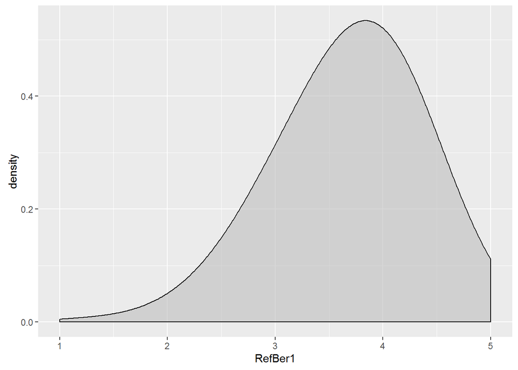

## willingness to reflect (attitude)

- source: adaption of Hosenfeld, A. (2010). *Führt Unterrichtsrückmeldung zu Unterrichtsentwicklung?* Die Wirkung von videographischer und schriftlicher Rückmeldung bei Lehrkräften der vierten Jahrgangsstufe. Zugl.: Koblenz-Landau, Univ., Diss., 2009. Empirische Erziehungswissenschaft. Münster, München, Berlin: Waxmann.
- question type: likert scale
- number of items: 5
- names and label of items:
  - T1_RefBer2_5 = “Wie sehr stimmen Sie folgenden Aussagen zu? **Ich nehme mir Zeit, um über Aufgabenlösungen zu reflektieren.**”
  - T1_RefBer2_6 = “Wie sehr stimmen Sie folgenden Aussagen zu? **Wenn ich Kritik oder Verbesserungsvorschläge höre, die meine Aufgabenerledigung betreffen, gehe ich darauf ein.**”
  - T1_RefBer2_7 = “Wie sehr stimmen Sie folgenden Aussagen zu? **Ich mache mir Gedanken über die Art und Weise, wie ich Aufgaben anpacke.**”
  - T1_RefBer2_8 = “Wie sehr stimmen Sie folgenden Aussagen zu? **Ich interessiere mich für meine eigenen Fehler, um daraus etwas über meine eigene Aufgabenbewältigung zu lernen.**”
  - T1_RefBer2_9 = “Wie sehr stimmen Sie folgenden Aussagen zu? **Die Forderung nach „Lebenslangem Lernen“ erfordert gerade im Lehrberuf, dass man ständig an sich arbeitet.**”
- value lables and numbers:
  - 1 = “stimme gar nicht zu”
  - 2 = “stimme eher nicht zu”
  - 3 = “stimme eher zu”
  - 4 = “stimme voll und ganz zu”
- inverted items: -
- subscales: -
- item statistics

| item | n | mean | sd | min | max |
| --- | --- | --- | --- | --- | --- |
| T1_RefBer2_5 | 623 | 2.93 | 0.6 | 1 | 4 |
| T1_RefBer2_6 | 622 | 3.34 | 0.56 | 1 | 4 |
| T1_RefBer2_7 | 622 | 3.31 | 0.67 | 1 | 4 |
| T1_RefBer2_8 | 620 | 3.4 | 0.6 | 1 | 4 |
| T1_RefBer2_9 | 623 | 3.7 | 0.5 | 2 | 4 |

- scale statistics

| n | mean | sd | min | max | McDonaldsOmega |
| --- | --- | --- | --- | --- | --- |
| 624 | 3.33 | 0.37 | 2 | 4 | 0.72 |

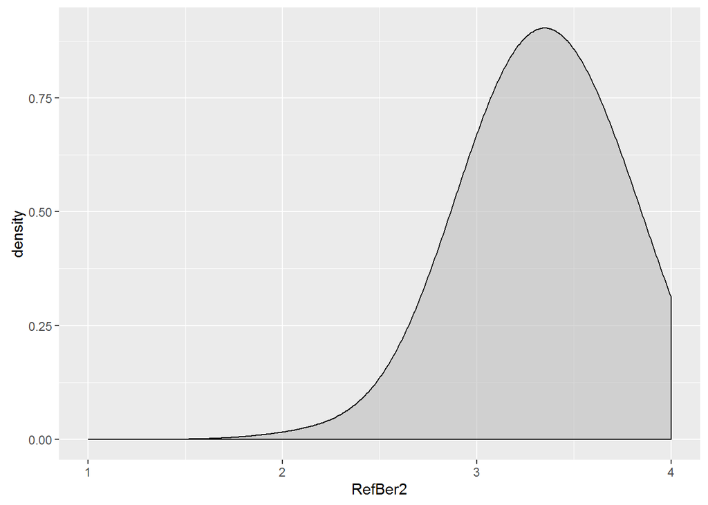

## expectancy value

- source: adaption of Eccles expectancy value model
- question type: likert scale
- number of items: 5
- names and label of items:
  - T1_ind_wert_intr = “Inwiefern stimmen Sie folgenden Aussagen zu? **Ich hätte gern mehr Seminare zum Thema Classroom-Management.**”
  - T1_ind_wert_util1 = “Inwiefern stimmen Sie folgenden Aussagen zu? **Gute Fähigkeiten im Classroom-Management werde ich für mein späteres Leben benötigen.**”
  - T1_ind_wert_cost1 = “Inwiefern stimmen Sie folgenden Aussagen zu? **Im Seminar muss ich viel Zeit aufwenden, um eine gute Note zu erzielen.**”
  - T1_ind_wert_cost2 = “Inwiefern stimmen Sie folgenden Aussagen zu? **Um im Seminar gut zu sein, müsste ich viel Freizeit opfern.**”
  - T1_ind_wert_util2 = “Inwiefern stimmen Sie folgenden Aussagen zu? **Eine gute Note im Seminar kann mir später sehr nutzen.**”
- value lables and numbers:
  - 1 = “stimmt gar nicht”
  - 2 = “stimmt eher nicht”
  - 3 = “stimmt eher”
  - 4 = “stimmt genau”
- inverted items: -
- subscales:
  - cost: T1_ind_wert_cost1, T1_ind_wert_cost2
  - utility: T1_ind_wert_util1, T1_ind_wert_util2
- item statistics

| item | n | mean | sd | min | max |
| --- | --- | --- | --- | --- | --- |
| T1_ind_wert_intr | 618 | 2.93 | 0.73 | 1 | 4 |
| T1_ind_wert_util1 | 616 | 3.55 | 0.58 | 1 | 4 |
| T1_ind_wert_cost1 | 614 | 2.86 | 0.71 | 1 | 4 |
| T1_ind_wert_cost2 | 613 | 2.64 | 0.77 | 1 | 4 |
| T1_ind_wert_util2 | 619 | 2.59 | 0.88 | 1 | 4 |

- subscale statistics

| subscale | n | mean | sd | min | max | McDonaldsOmega |
| --- | --- | --- | --- | --- | --- | --- |
| cost | 619 | 2.75 | 0.68 | 1 | 4 | 0.8 |
| utility | 621 | 3.07 | 0.56 | 1 | 4 | 0.19 |

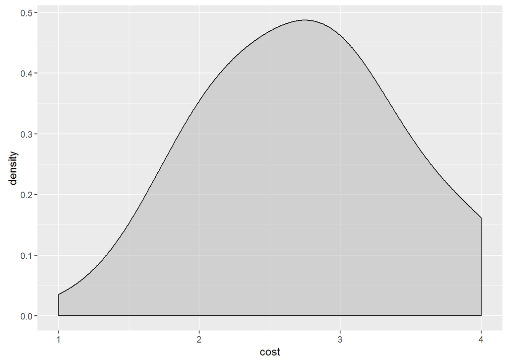

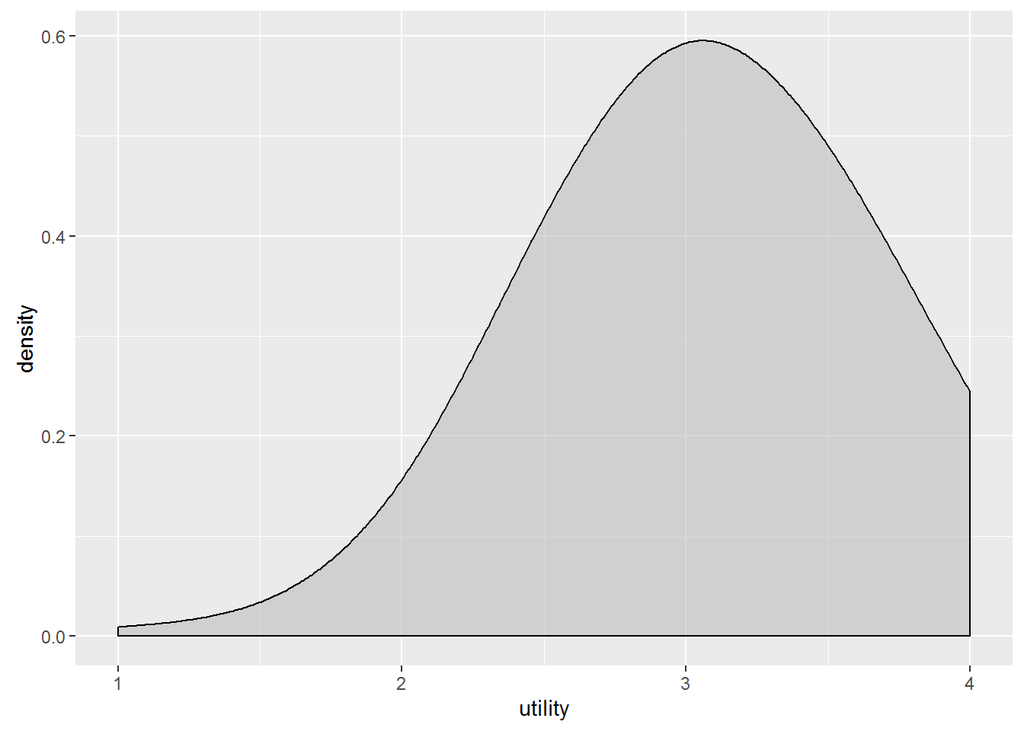

## willingness for effort

- source: adaption of SELLMO & TRAIN
- question type: likert scale
- number of items: 7
- names and label of items:
  - T1_anstrS_1 = “Worum geht es Ihnen im Seminar? Im Seminar geht es mir darum… **zu Hause keine Arbeit erledigen zu müssen.**”
  - T1_anstrS_2 = “Worum geht es Ihnen im Seminar? Im Seminar geht es mir darum… **aufwändige Aufgaben nicht selbst erledigen zu müssen.**”
  - T1_anstrS_3 = “Worum geht es Ihnen im Seminar? Im Seminar geht es mir darum… **mit wenig Arbeit durch die Veranstaltung zu kommen.**”
  - T1_anstrT_1 = “Wie sehr strengen Sie sich im Seminar an? **Ich bin im Seminar wirklich fleißig.**”
  - T1_anstrT_2 = “Wie sehr strengen Sie sich im Seminar an? **Ich tue im Seminar mein Bestes.**”
  - T1_anstrT_3 = “Wie sehr strengen Sie sich im Seminar an? **Ich strenge mich im Seminar wirklich an.**”
  - T1_anstrT_4 = “Wie sehr strengen Sie sich im Seminar an? **Im Seminar bearbeite ich alle Aufgaben und Hausaufgaben sehr ordentlich.**”
- value lables and numbers:
  - 1 = “stimmt gar nicht”
  - 2 = “stimmt eher nicht”
  - 3 = “stimmt eher”
  - 4 = “stimmt genau”
- inverted items: -
- subscales:
  - sellmo: T1_anstrS_1, T1_anstrS_2, T1_anstrS_3
  - train: T1_anstrT_1, T1_anstrT_2, T1_anstrT_3, T1_anstrT_4
- item statistics

[output not shown]

- subscale statistics

| subscale | n | mean | sd | min | max | McDonaldsOmega |
| --- | --- | --- | --- | --- | --- | --- |
| SELLMO | 620 | 2.07 | 0.64 | 1 | 4 | 0.87 |
| TRAIN | 624 | 2.67 | 0.59 | 1 | 4 | 0.86 |

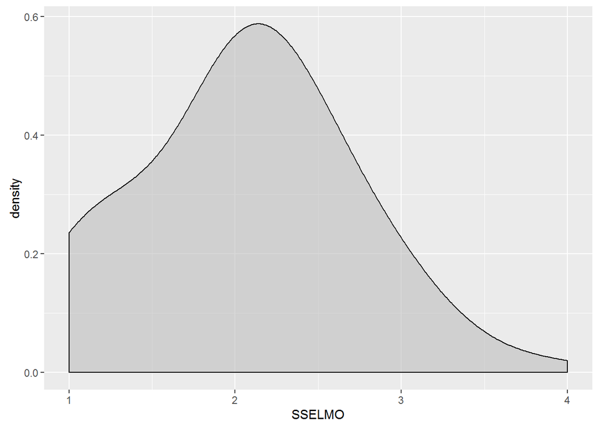

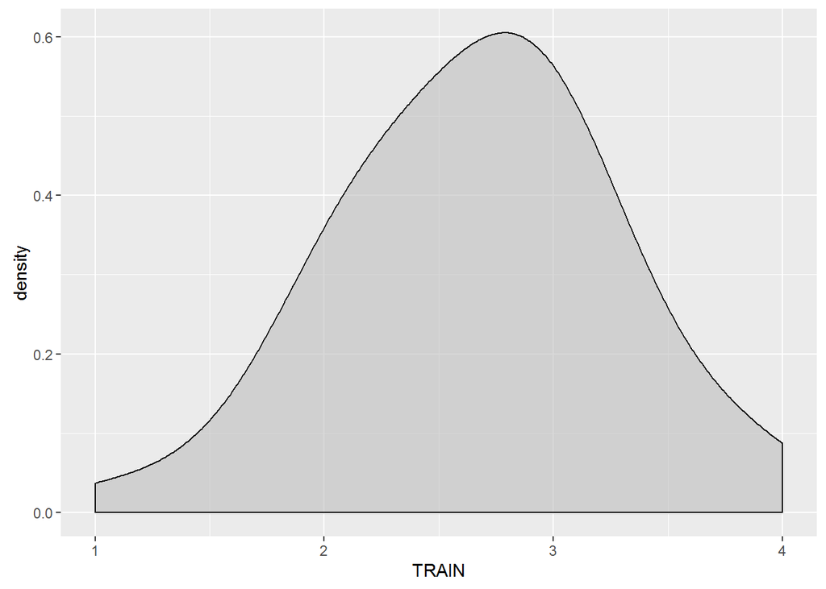

## constructivist learning beliefs

- source: adaption of Staub, F., & Stern, E. (2002). The nature of teacher’s pedagogical content beliefs matters for students’ achievement gains: quasi-experimental evidence from elementary mathematics. *Journal of Educational Psychology, 94* (2), 344-355.
- question type: likert scale
- number of items: 6
- names and label of items:
  - T1_knstr_1 = “Inwiefern stimmen Sie folgenden Aussagen zu? **Studierende lernen am besten, indem sie selbst Wege zur Lösung von Problemen entdecken.**”
  - T1_knstr_2 = “Inwiefern stimmen Sie folgenden Aussagen zu? **Man sollte Studierenden erlauben, sich eigene Wege zur Lösung von Anwendungsproblemen auszudenken, bevor die Lehrperson vorführt, wie diese zu lösen sind.**”
  - T1_knstr_3 = “Inwiefern stimmen Sie folgenden Aussagen zu? **Studierende können bei vielen Problemstellung auch ohne die Hilfe der Lehrenden Lösungswege finden.**”
  - T1_knstr_4 = “Inwiefern stimmen Sie folgenden Aussagen zu? **Pädagogik sollte so gelehrt werden, dass die Studierenden Zusammenhänge selbst entdecken können.**”
  - T1_knstr_5 = “Inwiefern stimmen Sie folgenden Aussagen zu? **Es hilft Studierenden, Pädagogik zu begreifen, wenn man sie ihre eigenen Lösungsideen diskutieren lässt.**”
  - T1_knstr_6 = “Inwiefern stimmen Sie folgenden Aussagen zu? **Studierende sollte häufig Gelegenheit gegeben werden, in Paaren/Kleingruppen Anwendungsprobleme gemeinsam zu lösen**”
- value lables and numbers:
  - 1 = “stimmt gar nicht”
  - 2 = “stimmt nur teilweise”
  - 3 = “stimmt größtenteils”
  - 4 = “stimmt genau”
- inverted items: -
- subscales: -
- item statistics

| item | n | mean | sd | min | max |
| --- | --- | --- | --- | --- | --- |
| T1_knstr_1 | 622 | 2.94 | 0.67 | 1 | 4 |
| T1_knstr_2 | 621 | 2.98 | 0.71 | 1 | 4 |
| T1_knstr_3 | 620 | 2.76 | 0.69 | 1 | 4 |
| T1_knstr_4 | 623 | 3.07 | 0.72 | 1 | 4 |
| T1_knstr_5 | 617 | 3.24 | 0.67 | 1 | 4 |
| T1_knstr_6 | 624 | 3.02 | 0.83 | 1 | 4 |

- scale statistics

| n | mean | sd | min | max | McDonaldsOmega |
| --- | --- | --- | --- | --- | --- |
| 624 | 3 | 0.45 | 1.33 | 4 | 0.76 |

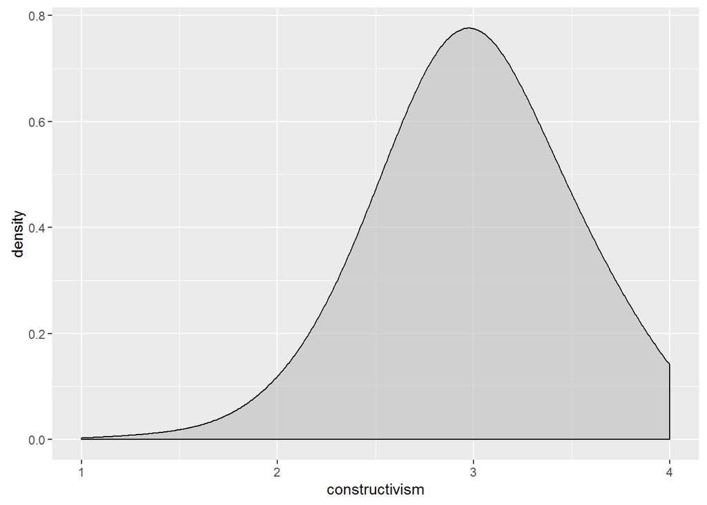

## interest in classroom management

- source: adaption of Anna-Lena Diecke
- question type: likert scale
- number of items: 6
- names and label of items:
  - T1_int_1 = “Wie interessant finden Sie Inhalte zum Thema Classroom Management? **Für das Thema Classroom Management interessiere ich mich.**”
  - T1_int_2 = “Wie interessant finden Sie Inhalte zum Thema Classroom Management? **Ich beschäftige mich gerne mit Büchern oder Aufgaben, die etwas mit dem Thema Classroom Management zu tun haben.**”
  - T1_int_3 = “Wie interessant finden Sie Inhalte zum Thema Classroom Management? **Die Beschäftigung mit dem Thema Classroom Management gehört zu meinen Lieblingstätigkeiten.**”
  - T1_int_4 = “Wie interessant finden Sie Inhalte zum Thema Classroom Management? **Oft finde ich das, was wir an der Universität zum Thema Classroom Management durchnehmen, richtig spannend.**”
  - T1_int_5 = “Wie interessant finden Sie Inhalte zum Thema Classroom Management? **Oft bin ich nach dem Seminar schon neugierig auf die nächste Sitzung.**”
  - T1_int_6 = “Wie interessant finden Sie Inhalte zum Thema Classroom Management? **Mit bestimmten Fragen zum Thema Classroom Management würde ich mich gern noch viel mehr beschäftigen.**”
- value lables and numbers:
  - 1 = “stimmt gar nicht”
  - 2 = “stimmt eher nicht”
  - 3 = “stimmt eher”
  - 4 = “stimmt genau”
- inverted items: -
- subscales: -
- item statistics

| item | n | mean | sd | min | max |
| --- | --- | --- | --- | --- | --- |
| T1_int_1 | 619 | 3.14 | 0.62 | 1 | 4 |
| T1_int_2 | 618 | 2.13 | 0.71 | 1 | 4 |
| T1_int_3 | 621 | 1.76 | 0.69 | 1 | 4 |
| T1_int_4 | 619 | 2.73 | 0.68 | 1 | 4 |
| T1_int_5 | 619 | 2.37 | 0.76 | 1 | 4 |
| T1_int_6 | 620 | 2.72 | 0.75 | 1 | 4 |

- scale statistics

| n | mean | sd | min | max | McDonaldsOmega |
| --- | --- | --- | --- | --- | --- |
| 623 | 2.48 | 0.47 | 1 | 4 | 0.82 |

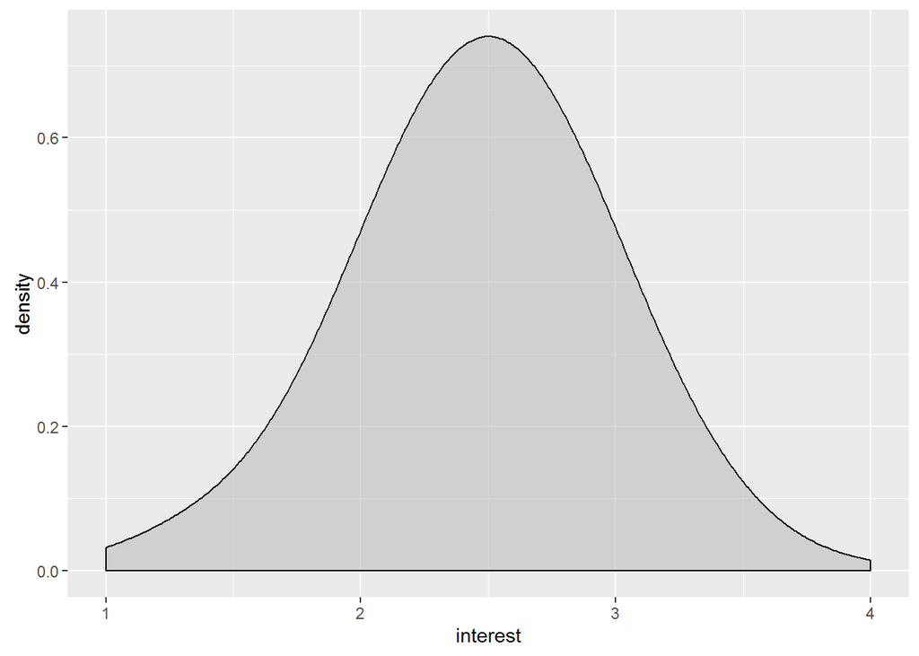

## practical relevance of the course

- source: adaption of COAKTIV, Pisa 2003
- question type: likert scale
- number of items: 5
- names and label of items:
  - T1_prak_1 = “Wie finden Sie die Inhalte im Seminar? **Im Seminar kann man kaum etwas lernen, was in der Wirklichkeit von Nutzen ist.**”
  - T1_prak_2 = “Wie finden Sie die Inhalte im Seminar? **Nur wenige Dinge, die wir im Seminar lernen, kann man später verwenden.**”
  - T1_prak_3 = “Wie finden Sie die Inhalte im Seminar? **Was wir im Seminar lernen, ist nützlich in vielen anderen Bereichen.**”
  - T1_prak_4 = “Wie finden Sie die Inhalte im Seminar? **Im Seminar beschäftigen wir uns mit Aufgaben, die einen praktischen Nutzen haben.**”
  - T1_prak_5 = “Wie finden Sie die Inhalte im Seminar? **Was wir im Seminar lernen, hilft, alltägliche Aufgaben und Probleme zu lösen.**”
- value lables and numbers:
  - 1 = “stimmt gar nicht”
  - 2 = “stimmt eher nicht”
  - 3 = “stimmt eher”
  - 4 = “stimmt genau”
- inverted items: T1_prak_1, T1_prak_2
- subscales: -
- item statistics

| item | n | mean | sd | min | max |
| --- | --- | --- | --- | --- | --- |
| T1_prak_1 recoded | 621 | 2.85 | 0.82 | 1 | 4 |
| T1_prak_2 recoded | 621 | 2.76 | 0.86 | 1 | 4 |
| T1_prak_3 | 620 | 2.64 | 0.74 | 1 | 4 |
| T1_prak_4 | 618 | 2.78 | 0.74 | 1 | 4 |
| T1_prak_5 | 619 | 2.32 | 0.81 | 1 | 4 |

- scale statistics

| n | mean | sd | min | max | McDonaldsOmega |
| --- | --- | --- | --- | --- | --- |
| 622 | 2.67 | 0.62 | 1 | 4 | 0.87 |

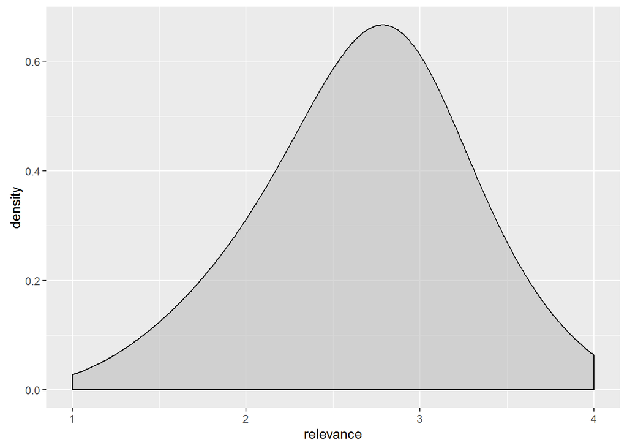

## attitude toward cooperative learning

- source: adaption of PISA 2000
- question type: likert scale
- number of items: 5
- names and label of items:
  - T1_koop_1 = “Inwiefern stimmen Sie den folgenden Aussagen zu? **Ich finde es nützlich, die Ideen von allen zusammen zu bringen, wenn man an einem Projekt arbeitet.**”
  - T1_koop_2 = “Inwiefern stimmen Sie den folgenden Aussagen zu? **Ich helfe anderen gern dabei, in einer Gruppe gute Arbeit zu leisten.**”
  - T1_koop_3 = “Inwiefern stimmen Sie den folgenden Aussagen zu? **Die beste Arbeit leiste ich, wenn ich mit anderen Studierenden zusammen arbeite.**”
  - T1_koop_4 = “Inwiefern stimmen Sie den folgenden Aussagen zu? **Am meisten lerne ich, wenn ich mit anderen Studierenden zusammen arbeite.**”
  - T1_koop_5 = “Inwiefern stimmen Sie den folgenden Aussagen zu? **Ich arbeite gern mit anderen Studierenden zusammen.**”
- value lables and numbers:
  - 1 = “trifft überhaupt nicht zu”
  - 2 = “”
  - 3 = “”
  - 4 = “”
  - 5 = “”
  - 6 = “”
  - 7 = “trifft voll und ganz zu”
- inverted items: -
- subscales: -
- item statistics

| item | n | mean | sd | min | max |
| --- | --- | --- | --- | --- | --- |
| T1_koop_1 | 621 | 5.59 | 1.18 | 1 | 7 |
| T1_koop_2 | 619 | 5.71 | 1.13 | 1 | 7 |
| T1_koop_3 | 621 | 4.43 | 1.54 | 1 | 7 |
| T1_koop_4 | 622 | 4.43 | 1.58 | 1 | 7 |
| T1_koop_5 | 622 | 5.34 | 1.45 | 1 | 7 |

- scale statistics

| n | mean | sd | min | max | McDonaldsOmega |
| --- | --- | --- | --- | --- | --- |
| 622 | 5.1 | 1.05 | 1.2 | 7 | 0.9 |

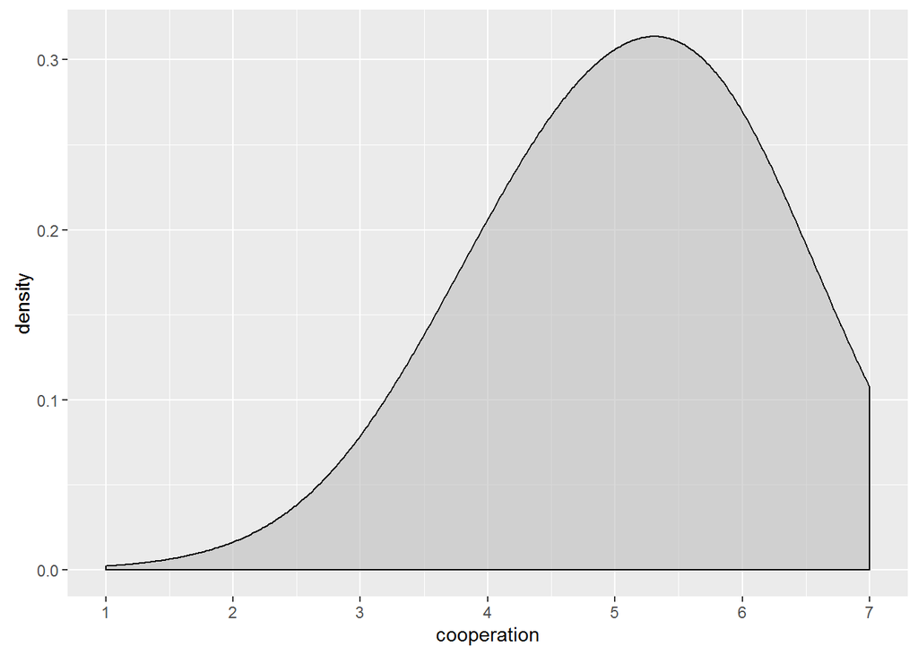

## self-perceived knowledge of classroom management

- source: own creation
- question type: likert scale
- number of items: 15
- names and label of items:
  - T1_wiss_crm_verh1 = “Bitte geben Sie Ihre Meinung an. **Ich kenne Strategien zum Umgang mit massiven Störungen.**”
  - T1_wiss_crm_verh2 = “Bitte geben Sie Ihre Meinung an. **Ich kenne verschiedene Möglichkeiten, auf Störungen zu reagieren, ohne den Unterrichtsfluss zu beeinträchtigen.**”
  - T1_wiss_crm_verh3 = “Bitte geben Sie Ihre Meinung an. **Ich kenne verschiedene Strategien, mit Regelverstößen umzugehen.**”
  - T1_wiss_crm_verh4 = “Bitte geben Sie Ihre Meinung an. **Ich weiß, wie ich auf Regelverstöße reagieren kann.**”
  - T1_wiss_crm_verh5 = “Bitte geben Sie Ihre Meinung an. **Ich kenne Möglichkeiten, präventiv Störungen zu vermeiden.**”
  - T1_wiss_crm_verh6 = “Bitte geben Sie Ihre Meinung an. **Ich kenne Prozeduren und Rituale, die zu einem reibungslosen Unterrichtsverlauf beitragen.**”
  - T1_wiss_crm_bez1 = “Bitte geben Sie Ihre Meinung an. **Ich kenne Möglichkeiten, mit Schülern ein Arbeitsbündnis herzustellen**”
  - T1_wiss_crm_bez2 = “Bitte geben Sie Ihre Meinung an. **Ich kenne Strategien, um Schüler zum Lernen zu motivieren.**”
  - T1_wiss_crm_unt1 = “Bitte geben Sie Ihre Meinung an. **Ich kenne verschiedene Strategien, um möglichst viele Schüler aktiv in den Unterricht einzubeziehen.**”
  - T1_wiss_crm_unt2 = “Bitte geben Sie Ihre Meinung an. **Ich weiß, wie ich unbeteiligte Schüler einbinden kann.**”
  - T1_wiss_crm_unt3 = “Bitte geben Sie Ihre Meinung an. **Ich kenne verschiedene Strategien, um den Schülern den roten Faden der Stunde zu verdeutlichen.**”
  - T1_wiss_crm_test = “Bitte geben Sie Ihre Meinung an. **Bitte kreuzen Sie in dieser Zeile „trifft vollkommen zu“ an.**”
  - T1_wiss_crm_unt4 = “Bitte geben Sie Ihre Meinung an. **Ich weiß, wie ich Aufgaben erklären muss, damit die Schüler sie verstehen.**”
  - T1_wiss_crm_unt5 = “Bitte geben Sie Ihre Meinung an. **Ich kenne Strategien, eine Stunde so zu planen, dass die Unterrichtszeit optimal genutzt werden kann.**”
  - T1_wiss_crm_unt6 = “Bitte geben Sie Ihre Meinung an. **Ich kenne Strategien, um Wartezeiten, Verzögerungen oder schleppende Übergänge zu vermeiden.**”
- value lables and numbers:
  - 1 = “trifft gar nicht zu”
  - 2 = “”
  - 3 = “”
  - 4 = “”
  - 5 = “”
  - 6 = “trifft vollkommen zu”
- inverted items: -
- subscales:
  - Verhaltenskontrolle: T1_wiss_crm_verh1, T1_wiss_crm_verh2, T1_wiss_crm_verh3, T1_wiss_crm_verh4, T1_wiss_crm_verh5, T1_wiss_crm_verh6
  - Beziehungsgestaltung: T1_wiss_crm_bez1, T1_wiss_crm_bez2
  - Unterrichtsgestaltung: T1_wiss_crm_unt1, T1_wiss_crm_unt2, T1_wiss_crm_unt3, T1_wiss_crm_unt4, T1_wiss_crm_unt5, T1_wiss_crm_unt6
  - control item : T1_wiss_crm_test
- item statistics

| item | n | mean | sd | min | max |
| --- | --- | --- | --- | --- | --- |
| T1_wiss_crm_verh1 | 619 | 3.34 | 1.27 | 1 | 6 |
| T1_wiss_crm_verh2 | 616 | 3.32 | 1.19 | 1 | 6 |
| T1_wiss_crm_verh3 | 618 | 3.57 | 1.2 | 1 | 6 |
| T1_wiss_crm_verh4 | 616 | 3.64 | 1.19 | 1 | 6 |
| T1_wiss_crm_verh5 | 616 | 3.52 | 1.28 | 1 | 6 |
| T1_wiss_crm_verh6 | 618 | 3.5 | 1.17 | 1 | 6 |
| T1_wiss_crm_bez1 | 617 | 3.63 | 1.21 | 1 | 6 |
| T1_wiss_crm_bez2 | 618 | 4.05 | 1.1 | 1 | 6 |
| T1_wiss_crm_unt1 | 614 | 4.04 | 1.12 | 1 | 6 |
| T1_wiss_crm_unt2 | 616 | 3.78 | 1.19 | 1 | 6 |
| T1_wiss_crm_unt3 | 613 | 3.97 | 1.17 | 1 | 6 |
| T1_wiss_crm_test | 610 | 5.81 | 0.8 | 1 | 6 |
| T1_wiss_crm_unt4 | 613 | 4.33 | 1.01 | 1 | 6 |
| T1_wiss_crm_unt5 | 618 | 3.41 | 1.24 | 1 | 6 |
| T1_wiss_crm_unt6 | 615 | 3.37 | 1.21 | 1 | 6 |

- subscale statistics

| subscale | n | mean | sd | min | max | McDonaldsOmega |
| --- | --- | --- | --- | --- | --- | --- |
| verhaltenskontrolle | 620 | 3.48 | 1 | 1 | 6 | 0.94 |
| beziehungsgestaltung | 619 | 3.84 | 1.03 | 1 | 6 | 0.73 |
| unterrichtsgestaltung | 619 | 3.82 | 0.87 | 1 | 6 | 0.9 |

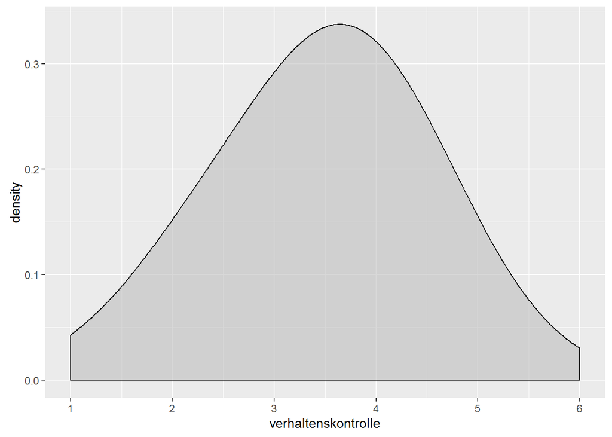

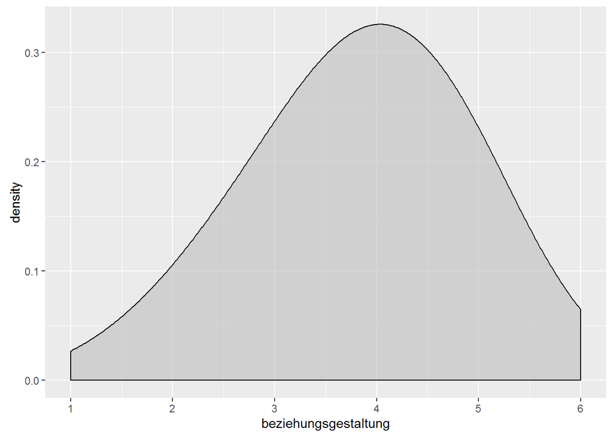

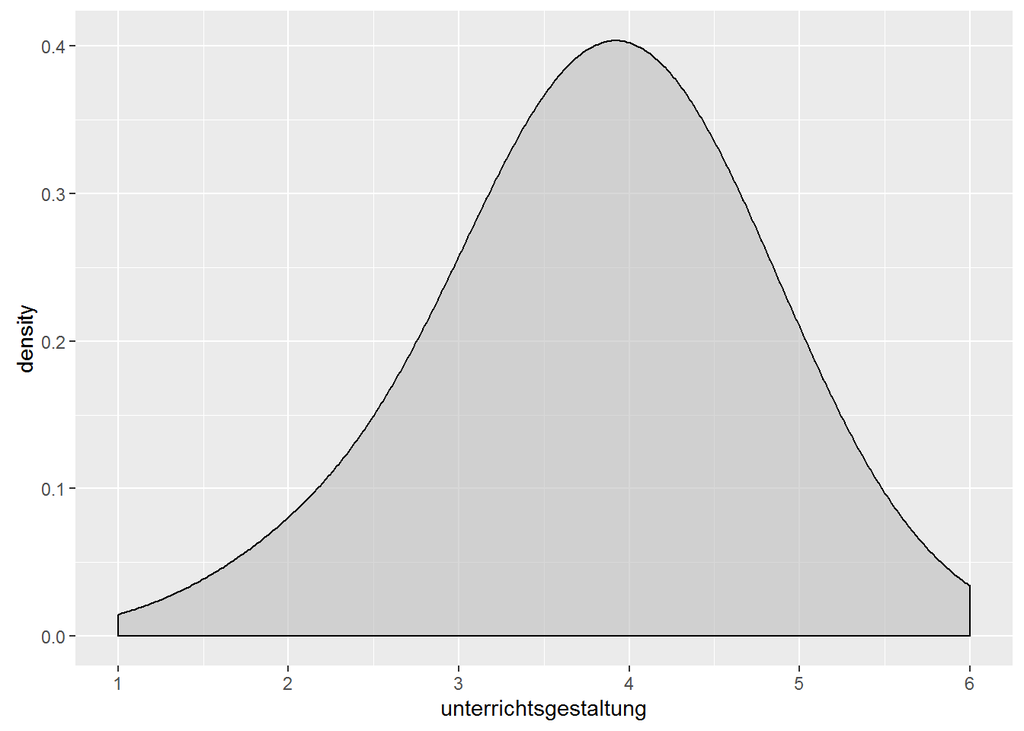